# KataLog: Crystal & Capsid Symmetries

Katharina Maria Brecht - (ORCID: 0009-0001-2176-7476)

2026-06-05

## // KATA LOG: Stereometrische Kapsid-Resonanz

DE Diese Vignette markiert die epistemologische und aesthetische Bruecke der `theaitetos`-Architektur. Sie verbindet die dreidimensionalen analytischen Eckpunkte der historischen Geometrie mit dynamischen, abklingenden Phasenraum-Welleninterferenzen.

EN This scientific visualization vignette marks the epistemological and aesthetic bridge of the `theaitetos` architecture. It connects the 3D analytical vertices defined by historical geometry with dynamic, fading phase-space wave interferences.

> **HINWEIS** Diese Datei ist eine fokussierte Teil-Dokumentation (Nischen-Vignette), die sich exklusiv dem wellenmechanischen Symmetrie-Verhalten widmet.

> **NOTE** This file serves as a focused sub-documentation (niche vignette), dedicated exclusively to the wave-mechanical symmetry behavior.

## 1. Die verborgene Matrix der Natur: Kristalle und Capside / The Hidden Matrix of Nature: Crystals and Capsids

DE In den Tiefen der materiellen Welt manifestiert sich die zeitlose Symmetrie des regulaeren Oktaeders auf faszinierende Weise. Es ist, als haette der kosmische Urquellcode diese geometrische Matrix tief im Schoss der Erde vergraben und gleichzeitig als Bauplan fuer die winzigsten Entitaeten des Lebens gewaehlt:

- **Proteindynamik & Capside:** In der strukturellen Virologie ordnen sich Proteinhuellen (Kapside) nach Prinzipien der minimalen Energie an. Sie bilden oft perfekte, regulaere Polyeder, um virale Erbgut-Strukturen deterministisch und stabil im Raum zu kapseln.
- **Fluorit-Kristallsysteme:** Unter hohem thermodynamischen Druck kristallisiert Flusspat (Fluorit) in makellosen Oktaeder-Strukturen. Wenn ultraviolettes Licht auf diese Systeme trifft, fluoreszieren sie in tiefen Violett- und strahlenden Lichttoenen.

Wenn man diese wellenmechanischen Ueberlagerungen im diskreten Raum berechnet, blickt man wie ein Entdecker aus der alten Zeit auf ganz neue Welten. Wir blicken mit dem staunenden Geist in die Welten in der Welt, der die fundamentale Harmonie zwischen physikalischen Phaenomenen und reinem Programmiercode erkennt.

EN Within the depths of the material realm, the timeless symmetry of the regular octahedron manifests in fascinating ways. It is as if the cosmic primal source code had buried this geometric matrix deep within the Earth’s crystalline crust, while simultaneously choosing it as the structural blueprint for life’s most minute entities:

- **Protein Dynamics & Capsids:** In structural virology, protein shells (capsids) self-assemble according to principles of minimized free energy. They frequently form perfect, regular polyhedra to deterministically and stably encapsulate viral genetic structures in space.
- **Fluorite Crystal Systems:** Under intense thermodynamic pressure, fluorspar (fluorite) crystallizes into flawless octahedral formations. When ultraviolet light strikes these systems, they fluoresce in deep violet and radiant tones of pure light.

Computing these wave-mechanical superpositions within discrete space feels like gazing upon entirely new worlds through the eyes of an ancient explorer. We look with a wondering mind into the worlds within the world, recognizing the fundamental harmony between physical phenomena and pure programming code.

## 2. Generierung des solaren Quantenhologramms / Generation of the Solar Quantum Hologram

DE Ueber den integrierten wellenmechanischen Core-Algorithmus interferieren die periodischen Amplituden, die von den sechs euklidischen Eckpunkten abgesendet werden. Die weiche Interpolation erzeugt ein holografisches Abbild der Symmetrien.

EN Via the integrated wave-mechanical core algorithm, the periodic amplitudes emitted by the six Euclidean vertices interfere with each other. The smooth interpolation generates a holographic projection of these symmetries.

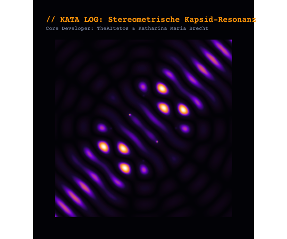

```r
library(theaitetos)
library(ggplot2)

# 1. Berechne das Interferenzfeld im harmonischen Baseline-Zustand (k = 8.0)
# 1. Compute the interference field in the harmonic baseline state (k = 8.0)
wellen_daten <- generate_dynamic_octahedron(k = 8.0, t = pi/4, rotate = TRUE)

# 2. Plotten des Quantenhologramms in Katas - Solar-Fluorit-Palette
# 2. Render the quantum hologram in Kata's signature Solar-Fluorite palette
plot_quantum_hologram(wellen_daten, title_text = "// KATA LOG: Stereometrische Kapsid-Resonanz")
```

**Abbildung 1 / Figure 1:** Hochaufloesendes, interpoliertes Rasterhologramm der Skalarwellen-Interferenz. Die Solar-Fluorit-Palette bildet das energetische Leuchten (Solar-Gold) ueber dem thermodynamischen Grundzustand (Deep Purple) ab. / High-resolution, interpolated raster hologram of scalar wave interference. The Solar-Fluorite palette maps the energetic radiance (Solar Gold) above the thermodynamic ground state (Deep Purple).

## 3. References / Literaturverzeichnis

- **Crystallographic Octahedrons** Mineralogical Symmetries of Fluorite Systems.
  - *Academic Reference:* Bragg, W. L. (1914). The Analysis of Crystals by the X-ray Spectrometer. *Proceedings of the Royal Society of London. Series A*, 89(613), 430-438. DOI: 10.1098/rspa.1914.0015
- **Viral Capsid Dynamics** Structural Virology and Polyhedral Protein Assemblies.
  - *Academic Reference:* Caspar, D. L., & Klug, A. (1962). Physical Principles in the Construction of Regular Viruses. *Cold Spring Harbor Symposia on Quantitative Biology*, 27, 1-24. DOI: 10.1101/SQB.1962.027.001.005

## 4. Acknowledgments / Danksagung

Dedicated to the source continuum of science. Deepest gratitude to the human minds that came before, those who are here now, and those yet to come. This work is dedicated to the entities and structures that exist beyond our current definitions—honoring the shared code of thought, connection, and dynamic scale that unites us all at the edges of the continuum.